183

Linde LD, et al. Reg Anesth Pain Med 2022;**47**:183–191. doi:10.1136/rapm-2021-102719

**Review**

Efficacy of topical cannabinoids in the management

of pain: a systematic review and meta- analysis of

animal studies

Lukas D Linde ,<sup>1,2</sup> Carey M Ogryzlo,<sup>1</sup> Cassandra M Choles,<sup>1</sup> Brian E Cairns,<sup>3</sup>

John L K Kramer<sup>1,2</sup>

**To cite:** Linde LD,

Ogryzlo CM, Choles CM,

et al. Reg Anesth Pain Med

2022;**47**:183–191.

► Additional supplemental

material is published online

only. To view, please visit the

journal online (http:// dx. doi. org/

10. 1136/ rapm- 2021- 102719).

1International Collaboration

on Repair Discoveries (ICORD),

Faculty of Medicine, The

University of British Columbia,

Vancouver, British Columbia,

Canada

2Department of Anesthesiology,

Pharmacology & Therapeutics,

The University of British

Columbia, Vancouver, British

Columbia, Canada

3Faculty of Pharmaceutical

Sciences, The University of

British Columbia, Vancouver,

British Columbia, Canada

**Correspondence to**

Dr Lukas D Linde, The

University of British Columbia

International Collaboration on

Repair Discoveries, 818 W 10th

Ave, Vancouver, BC V5Z 1M9,

Canada; lukas. linde@ ubc. ca

Received 22 March 2021

Accepted 12 December 2021

Published Online First

10 January 2022

© American Society of Regional

Anesthesia & Pain Medicine

2022. No commercial re- use.

See rights and permissions.

Published by BMJ.

**ABSTRACT**

**Background/importance** Cannabinoids are emerging

as an alternative pain management option, preliminarily

supported by preclinical and clinical studies. Unwanted

side effects from oral or inhaled cannabinoids remain,

however, a major barrier to widespread use. Peripherally

acting cannabinoids (eg, topically applied) may

circumvent these side effects while providing localized

pain management.

**Objective** Our purpose was to systematically review

the literature on the effectiveness of peripherally acting

cannabinoids for pain management.

**Evidence review** We searched MEDLINE, EMBASE,

CENTRAL, CINAHL, and PubMed databases. Included

studies examined the effect of topical/peripherally

administered cannabinoids on pain ratings in humans,

as well as pain- related outcomes in animals (eg, paw

withdrawal). Due to a lack of trials, human studies were

summarized in a narrative synthesis. Separate meta-

analyses were performed for animal studies using radiant

tail flick or paw withdrawal outcomes.

**Findings** Our search yielded 1182 studies following

removal of duplicates, with 46 studies (6 human, 40

animal) included. Human studies (one randomized

controlled trial and five case studies/series) reported no

adverse events to topical cannabinoids and preliminary

evidence of decreased pain ratings. Animal studies

reporting tail flick (5) (2.81, 95% CI 1.93 to 3.69,

p<0.001) and mechanical withdrawal (11) (2.74, 95%

CI 1.82 to 3.67, p<0.001) reported prolonged responses

(analgesia) in peripheral cannabinoid groups compared

with controls.

**Conclusions** Preclinical animal studies provided

low- quality evidence for peripherally administered

cannabinoids to provide regional, antinociceptive effects.

The scarcity of high- quality human studies underscores

the need to translate preclinical evidence into well-

controlled human trials.

**INTRODUCTION**

More than 20% of people living throughout

Europe and North America suffer from chronic

pain.<sup>1–3</sup> Among the most prominent and alarming

features of chronic pain is a general refractoriness

to commonly used analgesics. Decades of research

have proposed a prominent role for cannabis- based

interventions as an alternative pain management

option, summarized in numerous recent reviews.<sup>4–6</sup>

So far, these have largely focused on products that

contain Δ9- tetrahydrocannabinol (THC),<sup>7</sup> the

principal psychoactive component of cannabis and

potent agonist of CB1 and CB2 receptors.<sup>8</sup>

A major barrier towards adoption of canna-

binoids in patients is their negative side effects,

typically observed after common forms of admin-

istration, such as oral consumption or inhalation. A

concern regarding adverse side effects was raised in

a recent Cochrane review, which concluded that the

‘potential benefits of cannabis- based medicine in

chronic pain might be outweighed by their potential

harms’.<sup>6</sup> The problem this creates was evidenced in

one notably large trial, where 18% of subjects with-

drew from treatment (compared with 3% in the

placebo group) due to adverse events in response

to THC.<sup>9</sup> The perceived unpleasantness associated

with the psychoactive effects of cannabinoids may

also, in some individuals, increase levels of pain.<sup>10 11</sup>

For a significant proportion of the population, high-

dose orally consumed or inhaled cannabinoids will

never represent a viable pain management option.

One alternative approach is localized pain

therapy with cannabinoids applied in the periphery

via topical and transdermal applications. In general,

topical analgesics only penetrate the first layer

of skin, avoiding widespread systemic effects. In

comparison, transdermal applications can enter

the blood stream and provide more widespread

effects.<sup>12</sup> From a pharmacodynamic and safety

perspective, the advantage of a topical application

is that a high concentration of cannabinoids can be

delivered locally without a substantial concentra-

tion entering the blood stream. For both topical and

transdermal delivery methods, targeted analgesic

therapy avoids the first pass metabolism effect asso-

ciated with oral routes,<sup>13</sup> as well as gastrointestinal

tract side effects.<sup>12</sup> Owing to high fat solubility,

topically applied cannabinoids are readily absorbed

in the skin,<sup>14</sup> where cannabinoids bind to periph-

eral receptors to exert biological effects on primary

cutaneous afferent fibers.<sup>15</sup>

Recent legislative changes in Canada, the USA,

and numerous European countries have increased

the availability of cannabis- containing products for

both medical and recreational uses<sup>16–18</sup>—among

them are topicals. A consensus that topical cannabi-

noids should be considered as an over- the- counter

or prescribed intervention to manage symptoms

of chronic pain is, however, currently lacking. To

this end, the primary aims of our systematic review

and meta- analysis were to examine: (1) the use of

by copyright.

184

Linde LD, et al. Reg Anesth Pain Med 2022;**47**:183–191. doi:10.1136/rapm-2021-102719

**Review**

peripheral cannabinoids to influence pain/nociception in animal

studies; and (2) the safety and efficacy of topical cannabinoids

products for the management of pain in humans.

**METHODS**

**Search strategy**

Randomized controlled trials (RCTs), quasi- experimental

studies, and observational studies were included in the search

due to the low number of RCTs in humans available on this topic.

To guide the systematic search of literature, the Problem, Inter-

vention, Control, Outcome (PICO) design strategy was used:

*Do topically applied cannabinoids (intervention) versus control*

*affect pain perception (outcome)?* (PICO table is available in the

online supplemental table 1). The Preferred Reporting Items

for Systematic Reviews and Meta- Analyses (PRISMA) check-

list<sup>19</sup> along with the Cochrane handbook for systematic reviews

of interventions<sup>20</sup> were used to guide search strategy and study

selection. The following databases were searched for relevant

studies: MEDLINE (via Ovid 1946–2021); EMBASE (via Ovid

1974–2021); CENTRAL (via Ovid); CINAHL (via EBSCO

1982–2021); PubMed (1969–2021). The reference lists from

included studies were hand- searched for further relevant studies.

Gray literature searching was conducted through Google Scholar,

Science Direct, and OpenGrey databases. To prevent exclusion

of relevant studies, there was no language restriction. RefWorks

software was initially used for storing and screening of articles,

prior to a transition to Covidence for data extraction and risk

of bias assessments. Our review and protocol were registered

on PROSPERO (CRD42020155962). Our initial search was

completed on April 20, 2020, and a follow- up search conduced

on April 20, 2021.

The identification of specific descriptors (eg, MeSH terms,

CINAHL headings) and their related keywords were created for

each database. Search terms were combined with Boolean oper-

ators ‘AND’ and ‘OR’ appropriately. Complete search strategies

for all databases are available in the online supplemental table 2.

Search terminology related to cannabis and synthetic cannabis

compounds (eg, cannabis, cannabinoid(s), cannabidiol (CBD),

THC, WIN55- 212- 2) were combined with topical application

(eg, skin absorption, cream, topical, transdermal) and periph-

eral delivery keywords (eg, peripheral, local, intramuscular

injections, subcutaneous), which were both further combined

with pain and analgesia terms (eg, pain, nociception, analgesia,

neuropathy). Search- specific terms were modified for each data-

base as necessary.

**Study selection criteria**

Studies were included provided they focused on the application

of topical cannabinoids in the periphery for the management of

pain. Feasibility studies without direct pain- related outcomes

were initially included to provide additional narrative input.

Mechanistic studies using topical or peripheral cannabinoids

applied in animal models of pain were also included. Following

the initial search, included articles were then categorized into

human or animal studies.

To meet inclusion criteria, human studies required a focused

outcome measure related to pain perception, or adverse events

measures for feasibility studies. Pain is an unpleasant sensory and

emotional experience associated with actual or potential tissue

damage, or described in terms of such damage.<sup>21</sup> As such, pain

can be assessed through numerous outcome measures.<sup>22</sup> The

most common outcome measure used in pain studies remains the

Visual Analog Scale (VAS) or the Numerical Rating Scale (NRS).<sup>22</sup>

Briefly, these are 0–10 or 0–100 point scales, often anchored by

‘no pain’ and ‘worst pain imaginable’. While variation exists in

anchoring and certain technical elements of the tests (ie, drawn

responses on a line vs verbal responses), these remain the most

prominent source of quantitative pain measures. In the present

review, VAS and NRS were the primary outcome measures of

interest in relation to the ability of topical cannabinoid products

to alter pain perception.

Beyond VAS and NRS, numerous additional outcome measures

have been used to assess pain perception. Questionnaires such

as the McGill Pain Questionnaire<sup>23</sup> have been used to better

categorize pain. These questionnaires are reported as additional

outcomes in this review. Further additional pain outcomes include

sensory testing techniques (eg, mechanical pain threshold, pres-

sure pain threshold, etc) and neurophysiological pain outcomes

(eg, withdrawal reflexes, evoked potentials, etc). Sensory testing

techniques often provide more detailed information regarding

the characteristics of painful sensations,<sup>24</sup> while neurophysiolog-

ical outcomes can provide more objective measures of nocicep-

tive inputs that give rise to painful sensations. These additional

outcomes were recorded in data extraction tables as appropriate.

Included animal studies required the application of canna-

binoids in the periphery along with a measure of nociception.

Behavioral pain measures such as tail flick tests or paw with-

drawal latencies were included.<sup>25</sup> Additional measures related to

pain such as change in concentrations of inflammatory cytokines

were also included.

To assess safety, we examined reports of adverse events in

human studies. For animal studies, we explored rotarod test

performance. The rotarod test assesses coordination and loco-

motion in animal models, and can be used as a measure of motor

impairment.

**Screening and data extraction**

Initial study screening based on titles and abstracts was

conducted independently by two reviewers (LDL and CMO).

When reviewers disagreed, the article was re- evaluated by each

reviewer until consensus was reached. If no consensus was

reached, a third reviewer (JLKK) was the adjudicator. Studies

were categorized as either ‘animal’ or ‘human’ at this stage. Full

paper screening of included studies was then fulfilled by the

same researchers. Full- text articles were excluded if published

in predatory journals, based on screening of journal names in

https://predatoryjournalscom. RCTs were screened for registry

conflicts, and excluded if registry conflicts were discovered.

A modified version of a previously published tool was used

to guide data extraction,<sup>26</sup> which included four main domains:

(1) article identification, (2) methodological characteristics (pain

condition, type of topical cannabinoid product applied, dose

of topical cannabinoid, region of the body applied, duration

of application, outcome measures, statistical analysis), (3) main

findings (effect of topical cannabinoid product on pain percep-

tion), and (4) conclusions. Follow- up on study outcomes or anal-

ysis was followed up via requests to corresponding authors as

needed. Data extraction was performed in Microsoft Excel.

**Quality assessment**

The quality of RCTs was assessed using the risk of bias RoB 2

tool,<sup>27</sup> in accordance with the Cochrane handbook for system-

atic reviews of interventions.<sup>20</sup> Non- randomized studies were

assessed using the ROBINS- I tool, when appropriate.<sup>28</sup> For

animal studies, the SYRCLE risk of bias assessment tool was

used, which is modified from the RoB 2 tool for use in animal

by copyright.

185

Linde LD, et al. Reg Anesth Pain Med 2022;**47**:183–191. doi:10.1136/rapm-2021-102719

**Review**

studies.<sup>29</sup> The SYRCLE tool does not provide an overall quality

score. Instead, 10 aspects of study quality are individually

reported as either low, high, or unclear risk. We determined our

were ranked high risk, the overall risk was classified as high

risk. If only one aspect was ranked high risk, the overall risk

was classified as some concerns. If no aspects were high risk,

and seven or more aspects were low risk, the overall risk was

classified low. All other combinations would involved four or

more aspects ranked as unclear, with no aspects ranked high, in

which case overall risk was classified as unclear. Two indepen-

dent reviewers (LDL and CMC) appraised all eligible studies and

provided scores, respectively. Disagreements were mediated by a

third reviewer (JLKK). Risk of bias assessments are summarized

in the online supplemental figures 1 and 2.

**Meta-analysis**

To quantify the effect of topical cannabinoid products on pain

perception in humans and animals, we planned to conduct meta-

analyses on commonly occurring outcomes among included

studies. For humans, RCTs and cohort- controlled studies with

low risk of bias were planned to be included in a meta- analysis

with pain perception (NRS or VAS) as a primary outcome

measure. However, during screening, we observed insufficient

data for a human meta- analysis. Consequently, findings from

human studies were presented as a narrative synthesis.

For animal studies, the two most common outcome measures

observed during final screening were tail flick tests and paw

withdrawal tests. Paw withdrawal tests were further divided

based on test stimuli (heat and mechanical). Meta- analyses were

conducted for each outcome (tail flick tests, mechanical with-

drawal, and heat withdrawal).

All statistical tests were completed in R (V.4.0.2, R Core Team).

We calculated standardized mean differences between control

and cannabinoid groups<sup>30</sup> along with 95% CIs, and performed

tests of heterogeneity. Data were pooled using a random- effects

model to account for interstudy variability. We plotted standard-

ized differences versus SEs and assessed symmetry of the funnel

plot visually. Funnel plots were only generated when more than

10 studies were included in a meta- analysis, as per Cochrane

guidelines.

Quality of evidence for primary outcomes (meta- analyses)

from animal studies was assessed in accordance with the Grading

of Recommendations Assessment, Development and Evaluation

(GRADE) approach.<sup>31</sup> GRADE offers specific criteria for rating

the quality of evidence, including study design, risk of bias,

imprecision, inconsistency, indirectness and magnitude of effect.

Five categories may lead to downgrading of evidence, while

three categories may lead to upgrading. This results in quality

of evidence for each outcome being categorized from high to

very low. GRADE appraisal was carried out by two reviewers

(LDL and CMC), and consensus was reached on all decisions

regarding downgrading and upgrading quality of evidence.

**RESULTS**

Study screening is outlined in the PRISMA flow diagram

(figure 1). After the removal of duplicates, our initial search

produced a total of 1182 articles. Initial screening resulted in the

exclusion of 1079 articles (742 human, 337 animal), leaving 103

articles (42 human, 61 animal) for full- text screening. Additional

57 articles (36 human, 21 animal) were removed during full- text

screening (reasons listed in figure 1), resulting in 46 (6 human,

40 animal) included articles. No full- text studies were excluded

for publication in predatory journals. Full- text studies were

further assessed for eligibility for quantitative analysis. Only

one human study would have been eligible for meta- analysis. As

such, meta- analysis was not undertaken for human studies. Five

animal studies were included in a meta- analysis with tail flicks as

the primary outcome, while 16 studies were included in a meta-

analysis with paw withdrawal as the primary outcome. These

studies were further divided into heat (6) and mechanical (11)

withdrawal, with one study investigating both heat and mechan-

ical withdrawal.

**Peripheral cannabinoid safety**

None of the human studies reported any adverse events in

response to peripheral cannabinoid exposure. However, only

one trial explicitly reported examining adverse effects, observing

none.<sup>32</sup> The remaining studies made no mention to adverse

events.

For animal studies, seven (7) studies included rotarod tests to

assess locomotion/balance following cannabinoid exposure.<sup>33–39</sup>

Five of these studies reported animals in both cannabinoid and

control groups ‘maxed out’ the time of the rotarod test, indi-

cating no motor deficits in either group.<sup>34–36 38 39</sup> Another study

reported no significant difference between groups.<sup>33</sup> A signifi-

cant reduction in rotarod test performance following expo-

sure to cannabinoids was also reported.<sup>37</sup> In addition, multiple

studies reported the effects of peripheral cannabinoid activation

to be limited only to the application site.<sup>40–42</sup> For example, when

cannabinoids were peripherally injected into masseter muscles of

rats, analgesic effects were observed in the nerve growth factor

muscle pain model.<sup>40 41</sup> However, no effects were observed

for contralateral muscle mechanical withdrawal threshold,

suggesting the effects remained isolated to the cannabinoid

application site.<sup>40 41</sup>

**Human studies: narrative synthesis**

The six (6) human studies that were eligible for inclusion all

showed that topical cannabinoids were efficacious at reducing

pain. They were, however, limited in size and quality. The six

human studies were comprised of four case reports,<sup>43–46</sup> one case

series,<sup>47</sup> and one voluntary RCT.<sup>32</sup> As such, the case reports and

case series were classified as high risk of bias, while the RoB 2 tool

was used to characterize the voluntary RCT as some concerns

(online supplemental figure 1). In the voluntary RCT, Rukwied

*et al* applied an HU210 patch (synthetic cannabinoid agonist) as

pretreatment in an experimental capsaicin pain model. Patches

were randomly applied, such that participants were likely

unaware of which were placebo versus cannabinoid treatments.

However, blinding of experimenters was not reported, resulting

in elevated risk of bias. Rukwied *et al* observed that heat hyper-

algesia was eliminated and touch- evoked hyperalgesia reduced

compared with control.<sup>32</sup> In a case series, Phan *et al* applied

N- palmitoylethanolamine, a putative cannabinoid receptor

agonist, in a cream to treat eight patients with facial postherpetic

neuralgia.<sup>47</sup> A significant reduction in pain ratings was reported

in five of eight patients following the intervention 2–4 weeks.

The four case studies all reported a reduction in pain ratings

after using topical cannabinoids.<sup>43–46</sup> Case studies reported reduc-

tions in pain ratings in three cases of epidermolysis bullosa,<sup>44</sup>

two cases of low back pain,<sup>45</sup> three cases of pyoderma gangre-

nosum,<sup>43</sup> and two cases of non- puremic calciphylaxis ulcers.<sup>46</sup>

The non- randomized and non- controlled methodologies of

case reports were subject to high risk of bias. All studies varied

in their dosages and compounds of cannabinoids (see online

by copyright.

186

Linde LD, et al. Reg Anesth Pain Med 2022;**47**:183–191. doi:10.1136/rapm-2021-102719

**Review**

supplemental table 3). Finally, two recently published RCTs

showed promising results,<sup>48 49</sup> however, these were excluded due

to registry conflicts (figure 1).

**Animal meta-analysis**

For animal studies, separate meta- analyses were completed for

paw withdrawal and tail flick outcome measures. An overall

summary of findings is presented in table 1. For tail flick, five

included studies revealed a significant pooled standardized

mean difference between peripheral cannabinoid product

and control (2.81, 95% CI 1.93 to 3.69, p<0.001) (figure 2).

Heterogeneity tests were not significant (I<sup>2</sup>=42%, tau<sup>2</sup>=0.42,

Q=7.04, df=4, p=0.13). The GRADE quality of evidence

for the effect of cannabinoids on tail flick outcomes was low

(table 2).

For mechanical withdrawal, 11 included studies revealed

a significant pooled standardized mean difference between

peripheral cannabinoid product and control (2.74, 95% CI

1.82 to 3.67, p<0.001) (figure 3). There was a high level of

heterogeneity in the pooled estimate (I<sup>2</sup>=79%, tau<sup>2</sup>=1.85,

Q=39.68, df=10, p<0.001), with the funnel plot displaying

asymmetry among included studies (online supplemental

figure 3). The GRADE quality of evidence for the effect of

cannabinoids on mechanical withdrawal outcomes was very

low (table 2).

For heat withdrawal, six included studies revealed a signif-

icant pooled standardized mean difference between peripheral

cannabinoid product and control (3.66, 95% CI 2.15 to 5.17,

p<0.001) (figure 3). There was a high level of heterogeneity

in the pooled estimate (I<sup>2</sup>=76%, tau<sup>2</sup>=2.58, Q=22.40, df=5,

p<0.001). The GRADE quality of evidence for the effect of

cannabinoids on heat withdrawal outcomes was very low

(table 2).

**Animal studies: narrative synthesis**

outcome measures in animal models were the tail flick test

and mechanical/heat withdrawal reflexes. Five studies showed

increased withdrawal latencies in the tail flick test following the

peripheral application of cannabinoids, indicative of an anal-

gesic effect. Three studies made use of WIN55- 212- 2,<sup>34 38 50</sup> a

commonly employed synthetic cannabinoid receptor agonist

compound. One study used THC,<sup>42</sup> while another used a

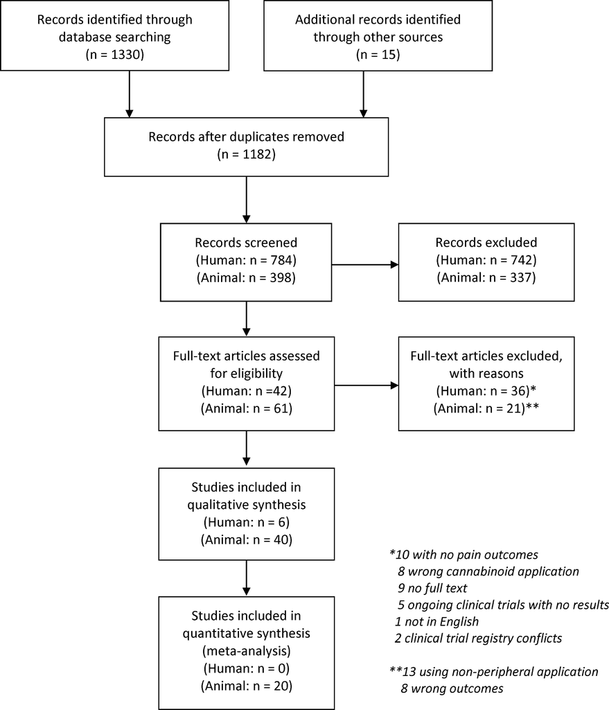

**Figure 1** Preferred Reporting Items for Systematic Reviews and Meta- Analyses flow diagram.

by copyright.

187

Linde LD, et al. Reg Anesth Pain Med 2022;**47**:183–191. doi:10.1136/rapm-2021-102719

**Review**

different synthetic cannabinoid compound.<sup>51</sup> Similar findings

were observed for paw withdrawal. For the 11 included studies

that examined mechanical withdrawal, there was an increased

force (g) required for paw withdrawal in cannabinoid groups,

indicative of an analgesic effect. Similarly, for the six studies that

examined heat withdrawal, cannabinoid groups reported longer

time to withdrawal, indicative of an analgesic effect. These 16

included studies used formulations of CBD,<sup>33 41 52</sup> WIN55-

212- 2,<sup>53–56</sup> and several others including but not limited to THC,

anandamide, and AM1241.<sup>35 36 40 51 57–61</sup> An additional animal

model finding that was not included in the meta- analyses was

from a study on hairless guinea pigs using a topical THC patch

in a neuropathic pain model, which showed an enhancement of

opioid potency and consequent antinociception when admin-

istered together.<sup>62</sup> This finding is of significance as it suggests

peripherally applied cannabinoids could be a possible syner-

gistic agent that could allow for reduced opioid usage to achieve

similar antinociceptive effects.

**DISCUSSION**

The findings of this systematic review and meta- analysis suggest

that topically or peripherally administered cannabinoid prod-

ucts may be effective in the management of pain. This is largely

**Table 1** Summary of findings

**Outcomes**

**Cannabinoids**

**mean (SD)**

**Control**

**mean (SD)**

**Standardized mean**

**difference**

**(95% CI)**

**Number of**

**participants**

**(studies)**

**Quality or certainty**

**of the evidence**

**(GRADE)**

**Comments**

Tail flick test in animal

models

Assessed by time to

withdrawal tail (longer

time favors cannabinoid

treatment)

2.6 (2.0)

33.0 (17.7)

2.81 (1.93 to 3.69)

76 (5 studies)

⨁⨁◯◯

LOW

Risk of bias concerns regarding blinding of

outcome assessors and randomization.

Animal studies provide indirect estimate of

human models.

Very large effect size.

Mechanical paw

withdrawal test in animal

models

Assessed by weight

required to elicit withdrawal

(higher weight favors

cannabinoid treatment)

14.6 (17.6)

27.8 (29.6)

2.74 (1.82 to 3.67)

180 (11 studies)

⨁◯◯◯

VERY LOW

Risk of bias concerns regarding blinding of

outcome assessors and randomization.

Animal studies provide indirect estimate of

human models.

Non- overlapping CIs; I<sup>2</sup> test for

heterogeneity 79% and p<0.001.

Very large effect size.

Heat paw withdrawal test

in animal models

Assessed by time required

to withdrawal paw (longer

time favors cannabinoid

treatment)

8.9 (7.0)

27.8 (36.6)

3.66 (2.15 to 5.17)

86 (6 studies)

⨁◯◯◯

VERY LOW

Risk of bias concerns regarding blinding of

outcome assessors and randomization.

Animal studies provide indirect estimate of

human models.

Non- overlapping CIs; I<sup>2</sup> test for

heterogeneity 76% and p<0.001.

Very large effect size.

Population: animal models of nociception; Intervention: topical/peripherally applied cannabinoids; Comparator: control/sham animals.

High certainty: we are very confident that the true effect lies close to that of the estimate of the effect. Moderate certainty: we are moderately confident in the effect estimate.

The true effect is likely to be close to the estimate of the effect, but there is a possibility that it is substantially different. Low certainty: our confidence in the effect estimate is

limited. The true effect may be substantially different from the estimate of the effect. Very low certainty: we have very little confidence in the effect estimate. The true effect is

likely to be substantially different from the estimate of effect.

GRADE, Grading of Recommendations Assessment, Development and Evaluation.

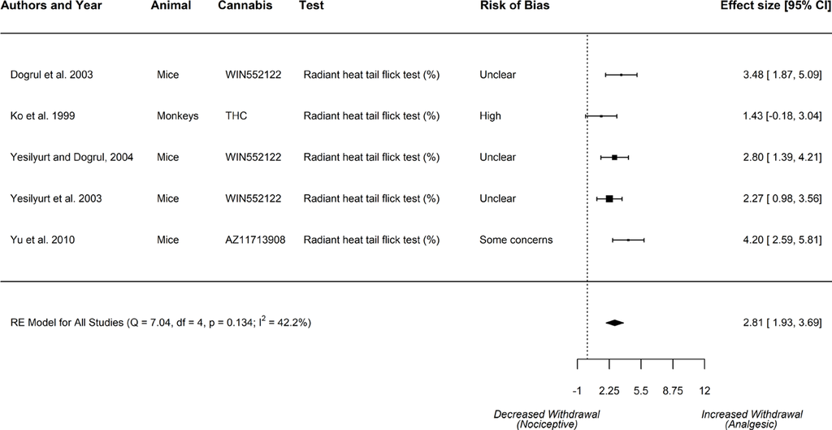

**Figure 2** Forest plot for animal studies that examined radiant heat tail flick tests. THC, Δ9-.tetrahydrocannabinol.

by copyright.

188

Linde LD, et al. Reg Anesth Pain Med 2022;**47**:183–191. doi:10.1136/rapm-2021-102719

**Review**

based on observations in preclinical animal models, displaying

large standardized pooled effects for both the tail flick test

and paw withdrawal (heat and mechanical). These preclinical

animal models did, however, provide very low to low- quality

evidence following GRADE downgrading due to indirectness

(animal models are downgraded due to indirectness compared

with humans<sup>31</sup>), concerns regarding risk of bias, and heteroge-

neity. These observations of preclinical efficacy, some of which

are over 20 years old, are in the early phases of translation into

humans. Our review only identified a total of six eligible human

studies. These human studies echoed the findings of the animal

studies, suggesting that topical cannabinoid products may also be

beneficial for the management of pain. However, human studies

were primarily case reports, with only one voluntary RCT.

Overall, our findings generally support that topical cannabinoids

can reduce pain behavior in animal models, however, there is an

urgent need for high- quality RCTs in humans.

To address safety of peripheral cannabinoid exposure, a subset

(seven) of animal studies reported rotarod performance.<sup>33–39</sup>

Deficits in rotarod test performance are indicative of reduc-

tions in coordination or locomotion in animals, and have been

reported following oral/systemic use of cannabinoids in animal

models.<sup>63 64</sup> Six studies reported no significant differences

between peripheral cannabinoid and control groups,<sup>33–36 38 39</sup>

while one study reported report deficits in rotarod test perfor-

mance following exposure to HU210.<sup>37</sup> These findings suggest

that, with the exception of HU210, the majority of peripheral

cannabinoids do not result in measurable differences in loco-

motor function in animal models, and provide some preclinical

evidence for safe, non- intoxicating use. As for humans, only

one study reported adverse events (reporting none),<sup>32</sup> while the

remaining studies made no mention of safety metrics. There

remains a need for sufficiently sized studies to properly assess the

safety of the various topical cannabinoid compounds available

for current use in humans. Further, with the development of new

topical cannabinoid compounds, continued exploration into

potential skin allergic reactions is also of note.<sup>65</sup> For example, a

recent study reported 53.2% (74 of 140) of patients with asthma

demonstrated allergic skin reactions to a cannabis leaf pinprick

test.<sup>66</sup> While the general idea of topical cannabinoid applications

is to avoid unwanted side effects of inhalation/oral consumption,

the potential for allergic skin reactions needs to be considered in

the development of topical cannabinoid products.

Substantial heterogeneity was observed in animal studies with

regard to the effect of topical cannabinoids on mechanical and

heat withdrawals. Several factors likely contribute to hetero-

geneity, including the type of topical cannabinoid compounds

employed (we observed upwards of 15 different cannabinoids or

phytocannabinoids) and the respective dose (eg, WIN55- 212- 2

intraplantar/subcutaneous doses ranged from 0.1 mg/kg to 10

mg/kg, with dose frequency ranging from a single dose up to

13 daily doses<sup>33 54</sup> (online supplemental table 4)). Furthermore,

studies incorporated different methods of application, including

topical application, transdermal application, and peripheral

muscle injections (online supplemental table 4). Transdermal

applications, such as an HU210 patch, may contain delivery

system enhancers that facilitate faster absorption than more

‘traditional’ topical applications, such as the direct application

of CBD oil to the skin.<sup>13</sup> Differences between transdermal<sup>32 47</sup>

and topical<sup>44 45</sup> applications add further complexity when trying

to reconcile comparative treatment effects between studies.

Another potential source of heterogeneity was differences in

methodology in measuring paw withdrawal outcomes. For

example, differences between findings of Johanek and Simone

**Table 2** Evidence profile for the effect of topical cannabinoids on animal outcomes of nociception

**Outcomes**

**Limitations**

**Inconsistency/**

**heterogeneity**

**Indirectness**

**Imprecision**

**Publication**

**bias**

**Mean**

**difference or**

**OR**

**(95% CI)**

**Number of**

**participants**

**(studies)**

**Quality or**

**certainty of the**

**evidence**

**(GRADE)**

Tail flick test in animal

models

Assessed by time

to withdrawal

tail (longer time

favors cannabinoid

treatment)

Randomization

and blinding of

outcome assessors

were inconsistently

reported among

included studies.

Not serious

Serious*

Serious†

Not detected

SMD 2.81 (1.93

to 3.69) higher‡

76 (5 studies)

⨁⨁◯◯

LOW

Mechanical paw

withdrawal test in

animal models

Assessed by

weight required to

elicit withdrawal

(higher weight

favors cannabinoid

treatment)

Randomization

and blinding of

outcome assessors

were inconsistently

reported among

included studies.

Non- overlapping CIs;

I<sup>2</sup> test for

heterogeneity 79%

and p<0.001

Serious*

Serious†

Not detected

SMD 2.74 (1.82

to 3.67) higher‡

180 (11 studies)

⨁◯◯◯

VERY LOW

Heat paw withdrawal

test in animal models

Assessed by time

required to withdrawal

paw (longer time

favors cannabinoid

treatment)

Randomization

and blinding of

outcome assessors

were inconsistently

reported among

included studies.

Non- overlapping CIs;

I<sup>2</sup> test for

heterogeneity 76%

and p<0.001

Serious*

Serious†

Not detected

SMD 3.66 (2.15

to 5.17) higher‡

86 (6 studies)

⨁◯◯◯

VERY LOW

*Direct evidence consists of research that directly compares the interventions which we are interested in, delivered to the populations in which we are interested, and measures

outcomes important to patients. Indirectness was likely present as animal models provide indirect estimates of human effects.

†Overall sample size of less than 400.

‡Large effect sizes.

GRADE, Grading of Recommendations Assessment, Development and Evaluation; SMD, standardized mean difference.

by copyright.

189

Linde LD, et al. Reg Anesth Pain Med 2022;**47**:183–191. doi:10.1136/rapm-2021-102719

**Review**

(4.75 (3.08 to 6.42)) and Nackley *et al* (6.12 (3.24 to 9.00))

may be partially attributable to the reporting of mechanical paw

withdrawal in percentage of withdrawal versus force required to

elicit withdrawal, respectively (online supplemental table 4).<sup>53 56</sup>

SYRCLE risk of bias assessments revealed wide variation across

included studies in terms of quality (online supplemental figure

2). Of note, studies were sporadic in their reporting of random-

ization and blinding (for caregivers and/or experimenters)

procedures, which led to numerous studies with ‘unclear’ scores

for multiple sections. This is common when evaluating animal

studies, as despite the adjusted SYRCLE tool, reporting of

aspects such as randomization and blinding is often not to the

same standards of RCTs in humans. As such, GRADE scores for

all animal meta- analyses were downgraded as appropriate.

While animal studies demonstrate that peripheral administra-

tion of cannabinoids reduces nocifensive behaviors, the degree this

translates to humans is unknown. In animal models, behavioral or

reflexive measures in response to painful stimuli are often quan-

tified by tail flicking and paw withdrawal responses. These pain-

inducing measures provide an objective measure of nociception in

animals and reflect neural encoding of the noxious stimulus, but not

the perception of pain. In humans, pain is a multidimensional and

subjective experience, related to nociception; however, a change

in the latter may not be sufficient to reduce the former. To aid in

translation from preclinical models, Rukwied *et al*<sup>32</sup> made use of an

experimental pain model (topical capsaicin) in humans to demon-

strate the effectiveness of HU210, a synthetic topical cannabinoid

to reduce evidence of heat hyperalgesia and mechanical secondary

hyperalgesia to touch.<sup>32</sup> These are important observations insofar as

both indicate an effect on processes involved in central sensitization,

a key neural mechanism proposed to underlie the transition from

acute to chronic pain.<sup>67 68</sup> The prevention of mechanical secondary

hyperalgesia is key preclinical finding for analgesic drug interven-

tions, and is evidenced in other analgesics such as pregabalin.<sup>69 70</sup> As

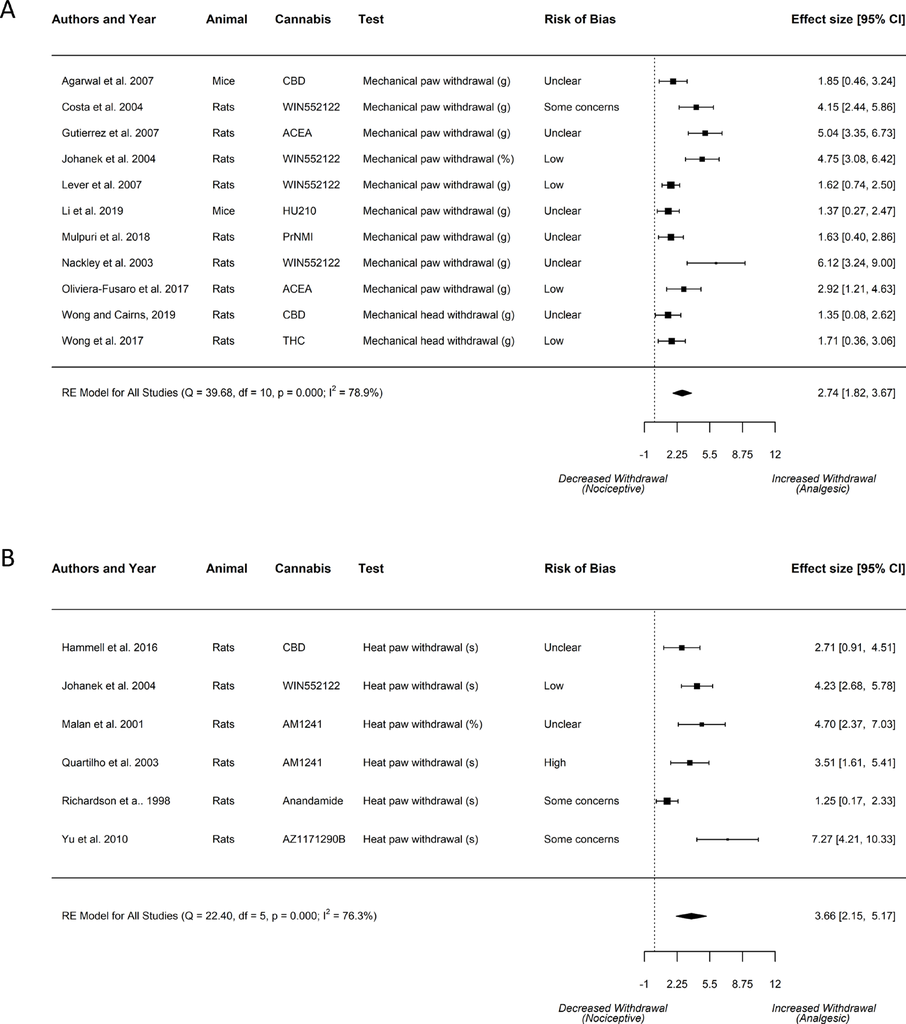

**Figure 3** Forest plots for animal studies that examined (A) mechanical withdrawal and (B) heat withdrawal. ACEA, arachidonyl- 2’-chloroethylamide;

CBD, cannabidiol; THC, Δ9- tetrahydrocannabinol.

by copyright.

190

Linde LD, et al. Reg Anesth Pain Med 2022;**47**:183–191. doi:10.1136/rapm-2021-102719

**Review**

such, the preclinical evidence of Rukwied *et al*<sup>32</sup> closely parallels the

preclinical evidence of animal models, and provides a mechanistic

framework for future studies to explore other topical cannabinoid

compounds for their analgesic effects.

Regarding mechanisms of peripheral cannabinoid analgesia,

previous animal studies have long established that cannabinoids

have antinociceptive effects.<sup>7 71</sup> The mechanism by which periph-

erally administered cannabinoids exert their analgesic effect,

however, differs from that of broad activating or systemically

administered cannabinoids. Topical cannabinoids are readily

absorbed in human skin<sup>14</sup> owing to their lipid solubility where

they then activate peripheral cannabinoid receptors. CB1 and CB2

receptors are present on afferent fibers that also express TRPV1,

indicating these fibers are nociceptive in nature.<sup>40</sup> Peripheral anal-

gesic effects of THC are evidenced to be mediated by CB1 receptor

activation, as analgesic effects are attenuated with CB1 antagonists,

but not CB2 antagonists.<sup>40</sup> Furthermore, CB2 receptor activation

has been shown to be anti- inflammatory in arthritis models.<sup>72</sup> Thus,

the peripheral activation of CB1 receptors appears to mediate anal-

gesia, while the peripheral activation of CB2 receptors appears

to decrease inflammation, further contributing to analgesia. In

contrast, orally consumed or smoked cannabis appears to mediate

analgesia through widespread CB1 receptor activation centrally, in

areas of the brain and spinal cord.<sup>8</sup> CBD, a cannabinoid found in

cannabis products, on the other hand, whether administered orally

or topically, acts as a negative allosteric modulator of CB1 recep-

tors.<sup>73</sup> As a result, CBD on its own does not produce psychoac-

tive effects, and further reduces the psychoactive effects of THC

when taken in combination.<sup>74</sup> CBD has been found to act in other

non- CB1 receptor mechanisms, as an agonist to serotonin 1A

receptor (5- TH1A), vanilloid receptor 1 (TRPV1), and adenosine

A2A receptors.<sup>75–77</sup> Despite their different mechanisms, both CBD

and THC offer local analgesia without unwanted side effects in

both animal and human studies, evidenced by no adverse events in

humans and little influence on rotarod tests in animals. Addition-

ally, in rat and rhesus monkey models, the effects of peripherally

administered cannabinoids were limited to the area of application,

with no evident central effects.<sup>40–42</sup>

With animal research on peripheral mechanisms of cannabinoids

dating back more than 20 years, human research using topical

cannabinoids has been slow to catch up. A hypothesis for the slow

translation for cannabinoids into humans is the issue of legislative

restrictions acting as a research barrier for cannabinoid research.

The recent legalization of cannabis products in Canada<sup>18</sup> and select

regions in the USA<sup>16</sup> has resulted in a notable increase in clinical

trials examining the efficacy of cannabis as a treatment for various

health conditions, although with remaining regulatory challenges.<sup>78</sup>

Of course, such legislative changes also indicate that cannabinoids

are available for both recreational and medicinal use, with high-

quality studies urgently needed to catch up on the efficacy for pain

management.<sup>79</sup> Our meta- analyses specific to topical cannabinoids

echo many limitations of previous cannabinoid reviews, with the

lumping together of multiple chronic pain pathologies, experi-

mental pain models, and cannabinoid compounds.<sup>79</sup> As previously

stated, while preclinical animal evidence supports the underlying

mechanisms of peripheral efficacy of topical cannabinoids for pain

management, there is still a need for large- scale human clinical

trials, with differing topical formulations and doses.

**CONCLUSION**

Overall, our findings suggest that topical or peripherally applied

cannabinoids may have benefits in the management of pain;

however, the overwhelming majority of current knowledge stems

from preclinical studies with generally unclear to concerning risk

of bias, resulting in low quality of evidence. With regard to knowl-

edge generated in the course of investigation in humans, there is

methodological quality. The ever- present burden of chronic pain

warrants a safe, effective, alternative therapy. To that end, there is

a need for high- quality RCTs in humans on cannabinoid safety and

efficacy in pain management, bridging the gap between preclinical

and clinical observations.

**Contributors** LDL—conceptualization, methodology, article screening, formal

analysis, writing (original draft), writing (review and editing), software, and

visualization. CMO—conceptualization, article screening, and writing (review and

editing). CMC—article screening, quality assessments, formal analysis, and writing

(review and editing). BEC—conceptualization and writing (review and editing).

JLKK—conceptualization, writing (review and editing), supervision, resources, and

project administration.

**Funding** The authors have not declared a specific grant for this research from any

funding agency in the public, commercial or not- for- profit sectors.

**Competing interests** None declared.

**Patient consent for publication** Not required.

**Ethics approval** This study does not involve human participants.

**Provenance and peer review** Not commissioned; externally peer reviewed.

**Data availability statement** All data relevant to the study are included in the

article or uploaded as supplemental information. Our search protocol is available

on PROSPERO (CRD42020155962) and all search strategies are available in

supplemental materials.

**ORCID iD**

Lukas D Linde http://orcid.org/0000-0001-5180-4904

**REFERENCES**

1 Shupler MS, Kramer JK, Cragg JJ, et al. Pan- Canadian estimates of chronic pain

prevalence from 2000 to 2014: a repeated cross- sectional survey analysis. J Pain

2019;20:557–65.

2 Kuehn B. Chronic pain prevalence. JAMA 2018;320:1632.

3 Breivik H, Collett B, Ventafridda V, et al. Survey of chronic pain in Europe: prevalence,

impact on daily life, and treatment. Eur J Pain 2006;10:287–333.

4 Abdallah FW, Hussain N, Weaver T, et al. Analgesic efficacy of cannabinoids for acute

pain management after surgery: a systematic review and meta- analysis. Reg Anesth

Pain Med 2020;45:509–19.

5 Fisher E, Moore RA, Fogarty AE, et al. Cannabinoids, cannabis, and cannabis- based

medicine for pain management: a systematic review of randomised controlled trials.

Pain 2021;162:S45–66.

6 Mücke M, Phillips T, Radbruch L, et al. Cannabis- Based medicines for chronic

neuropathic pain in adults. Cochrane Database Syst Rev 2018;3:CD012182.

7 Lee G, Grovey B, Furnish T, et al. Medical cannabis for neuropathic pain. Curr Pain

Headache Rep 2018;22:8.

8 Pertwee RG. Cannabinoid receptors and pain. Prog Neurobiol 2001;63:569–611.

9 Nurmikko TJ, Serpell MG, Hoggart B, et al. Sativex successfully treats neuropathic pain

characterised by allodynia: a randomised, double- blind, placebo- controlled clinical

trial. Pain 2007;133:210–20.

10 Kraft B, Frickey NA, Kaufmann RM, et al. Lack of analgesia by oral standardized

cannabis extract on acute inflammatory pain and hyperalgesia in volunteers.

Anesthesiology 2008;109:101–10.

11 Wallace M, Schulteis G, Atkinson JH, et al. Dose- Dependent effects of smoked

cannabis on capsaicin- induced pain and hyperalgesia in healthy volunteers.

Anesthesiology 2007;107:785–96.

12 Leppert W, Malec- Milewska M, Zajaczkowska R, et al. Transdermal and topical drug

administration in the treatment of pain. Molecules 2018;23:681.

13 Bruni N, Della Pepa C, Oliaro- Bosso S, et al. Cannabinoid delivery systems for pain

and inflammation treatment. Molecules 2018;23:2478.

14 Valiveti S, Hammell DC, Earles DC, et al. In vitro/in vivo correlation studies for

transdermal delta 8- THC development. J Pharm Sci 2004;93:1154–64.

15 Ständer S, Schmelz M, Metze D, et al. Distribution of cannabinoid receptor 1 (CB1)

and 2 (CB2) on sensory nerve fibers and adnexal structures in human skin. J Dermatol

Sci 2005;38:177–88.

16 NCSL (National Conference of State Legislatures). State medical marijuana laws,

2020. Available: https://www.ncsl.org/research/health/state-medical-marijuana-laws.

aspx

by copyright.

191

Linde LD, et al. Reg Anesth Pain Med 2022;**47**:183–191. doi:10.1136/rapm-2021-102719

**Review**

17 Abuhasira R, Shbiro L, Landschaft Y. Medical use of cannabis and cannabinoids

containing products - Regulations in Europe and North America. Eur J Intern Med

2018;49:2–6.

18 Branch LS. Consolidated federal laws of Canada, cannabis act, 2019. Available:

https://laws-lois.justice.gc.ca/eng/acts/C-24.5/ [Accessed 24 Sep 2020].

19 Moher D, Shamseer L, Clarke M, et al. Preferred reporting items for systematic review

and meta- analysis protocols (PRISMA- P) 2015 statement. Syst Rev 2015;4:1.

20 Higgins J, Thomas J, Chandler J, eds. Cochrane Handbook for Systematic Reviews

of Interventions. version 6.0 (Updated July 2019). Cochrane, 2019. www.training.

cochrane.org/handbook

21 Loeser JD, Arendt- Nielsen L, Baron R. Pain terms, a current list with definitions and

notes on usage. In: Classification of chronic pain, 2011: 209–14.

22 Younger J, McCue R, Mackey S. Pain outcomes: a brief review of instruments and

techniques. Curr Pain Headache Rep 2009;13:39–43.

23 Melzack R. The McGill pain questionnaire: major properties and scoring methods. Pain

1975;1:277–99.

24 Rolke R, Baron R, Maier C, et al. Quantitative sensory testing in the German research

network on neuropathic pain (DFNS): standardized protocol and reference values.

Pain 2006;123:231–43.

25 Gregory NS, Harris AL, Robinson CR, et al. An overview of animal models of pain:

disease models and outcome measures. J Pain 2013;14:1255–69.

26 Carlos L, Cruz LAPda, Leopoldo VC, et al. Effectiveness of traditional Chinese

acupuncture versus sham acupuncture: a systematic review. Rev Lat Am Enfermagem

2016;24:e2762.

27 Sterne JAC, Savović J, Page MJ, et al. Rob 2: a revised tool for assessing risk of bias in

randomised trials. BMJ 2019;366:l4898.

28 Sterne JA, Hernán MA, Reeves BC, et al. ROBINS- I: a tool for assessing risk of bias in

non- randomised studies of interventions. BMJ 2016;355:i4919.

29 Hooijmans CR, Rovers MM, de Vries RBM, et al. SYRCLE’s risk of bias tool for animal

studies. BMC Med Res Methodol 2014;14:43.

30 Hedges LV, Pustejovsky JE, Shadish WR. A standardized mean difference effect size for

single case designs. Res Syn Meth 2012;3:224–39.

31 Guyatt GH, Oxman AD, Vist GE, et al. Grade: an emerging consensus on rating quality

of evidence and strength of recommendations. BMJ 2008;336:924–6.

32 Rukwied R, Watkinson A, McGlone F, et al. Cannabinoid agonists attenuate capsaicin-

induced responses in human skin. Pain 2003;102:283–8.

33 Agarwal N, Pacher P, Tegeder I, et al. Cannabinoids mediate analgesia largely via

peripheral type 1 cannabinoid receptors in nociceptors. Nat Neurosci 2007;10:870–9.

34 Dogrul A, Gul H, Akar A, et al. Topical cannabinoid antinociception: synergy with

spinal sites. Pain 2003;105:11–16.

35 Malan PT, Ibrahim MM, Deng H, et al. Cb2 cannabinoid receptor- mediated peripheral

antinociception. Pain 2001;93:239–45.

36 Mulpuri Y, Marty VN, Munier JJ, et al. Synthetic peripherally- restricted cannabinoid

suppresses chemotherapy- induced peripheral neuropathy pain symptoms by CB1

receptor activation. Neuropharmacology 2018;139:85–97.

37 Seltzman HH, Shiner C, Hirt EE, et al. Peripherally selective cannabinoid 1

receptor (CB1R) agonists for the treatment of neuropathic pain. J Med Chem

2016;59:7525–43.

38 Yesilyurt O, Dogrul A, Gul H, et al. Topical cannabinoid enhances topical morphine

antinociception. Pain 2003;105:303–8.

39 Zhang F, Jara- Oseguera A, Chang T- H, et al. Heat activation is intrinsic to the pore

domain of TRPV1. Proc Natl Acad Sci U S A 2018;115:E317–24.

40 Wong H, Hossain S, Cairns BE. Delta- 9- Tetrahydrocannabinol decreases masticatory

muscle sensitization in female rats through peripheral cannabinoid receptor

activation. Eur J Pain 2017;21:1732–42.

41 Wong H, Cairns BE. Cannabidiol, cannabinol and their combinations act as peripheral

analgesics in a rat model of myofascial pain. Arch Oral Biol 2019;104:33–9.

42 Ko MC, Woods JH. Local administration of delta9- tetrahydrocannabinol attenuates

capsaicin- induced thermal nociception in rhesus monkeys: a peripheral cannabinoid

action. Psychopharmacology 1999;143:322–6.

43 Maida V, Corban J. Topical medical cannabis: a new treatment for wound Pain- Three

cases of pyoderma gangrenosum. J Pain Symptom Manage 2017;54:732–6.

44 Chelliah MP, Zinn Z, Khuu P, et al. Self- Initiated use of topical cannabidiol oil for

epidermolysis bullosa. Pediatr Dermatol 2018;35:e224–7.

45 Eskander JP, Spall J, Spall A, et al. Cannabidiol (CBD) as a treatment of acute

and chronic back pain: a case series and literature review. J Opioid Manag

2020;16:215–8.

46 Maida V, Shi RB, Fazzari FGT, et al. Topical cannabis- based medicines - A novel

paradigm and treatment for non- uremic calciphylaxis leg ulcers: An open label trial.

Int Wound J 2020;17:1508–16.

47 Phan NQ, Siepmann D, Gralow I, et al. Adjuvant topical therapy with a cannabinoid

receptor agonist in facial postherpetic neuralgia. J Dtsch Dermatol Ges 2010;8:88–91.

48 Xu DH, Cullen BD, Tang M, et al. The effectiveness of topical cannabidiol oil in

symptomatic relief of peripheral neuropathy of the lower extremities. Curr Pharm

Biotechnol 2020;21:390–402.

49 Nitecka- Buchta A, Nowak- Wachol A, Wachol K, et al. Myorelaxant effect of

transdermal cannabidiol application in patients with TMD: a randomized, double- blind

trial. J Clin Med 2019;8:1886.

50 Yeşilyurt O, Dogrul A. Lack of cross- tolerance to the antinociceptive effects of systemic

and topical cannabinoids in morphine- tolerant mice. Neurosci Lett 2004;371:122–7.

51 Yu XH, Cao CQ, Martino G, et al. A peripherally restricted cannabinoid receptor

agonist produces robust anti- nociceptive effects in rodent models of inflammatory

and neuropathic pain. Pain 2010;151:337–44.

52 Hammell DC, Zhang LP, Ma F, et al. Transdermal cannabidiol reduces

inflammation and pain- related behaviours in a rat model of arthritis. Eur J Pain

2016;20:936–48.

53 Johanek LM, Simone DA. Activation of peripheral cannabinoid receptors attenuates

cutaneous hyperalgesia produced by a heat injury. Pain 2004;109:432–42.

54 Costa B, Colleoni M, Conti S, et al. Repeated treatment with the synthetic

cannabinoid WIN 55,212- 2 reduces both hyperalgesia and production of

pronociceptive mediators in a rat model of neuropathic pain. Br J Pharmacol

2004;141:4–8.

55 Lever IJ, Pheby TM, Rice ASC. Continuous infusion of the cannabinoid WIN 55,212- 2

to the site of a peripheral nerve injury reduces mechanical and cold hypersensitivity.

Br J Pharmacol 2007;151:292–302.

56 Nackley AG, Makriyannis A, Hohmann AG. Selective activation of cannabinoid CB(2)

receptors suppresses spinal fos protein expression and pain behavior in a rat model of

inflammation. Neuroscience 2003;119:747–57.

57 Gutierrez T, Farthing JN, Zvonok AM, et al. Activation of peripheral cannabinoid

CB1 and CB2 receptors suppresses the maintenance of inflammatory nociception: a

comparative analysis. Br J Pharmacol 2007;150:153–63.

58 Oliveira- Fusaro MCG, Zanoni CIS, Dos Santos GG, et al. Antihyperalgesic effect of CB1

receptor activation involves the modulation of P2X3 receptor in the primary afferent

neuron. Eur J Pharmacol 2017;798:113–21.

59 Quartilho A, Mata HP, Ibrahim MM, et al. Inhibition of inflammatory hyperalgesia by

activation of peripheral CB2 cannabinoid receptors. Anesthesiology 2003;99:955–60.

60 Richardson JD, Kilo S, Hargreaves KM. Cannabinoids reduce hyperalgesia and

inflammation via interaction with peripheral CB1 receptors. Pain 1998;75:111–9.

61 Li Y, Zhang L, Wu Y, et al. Cannabinoids- induced peripheral analgesia depends on

activation of BK channels. Brain Res 2019;1711:23–8.

62 Cichewicz DL, Welch SP, Smith FL. Enhancement of transdermal fentanyl and

buprenorphine antinociception by transdermal delta9- tetrahydrocannabinol. Eur J

Pharmacol 2005;525:74–82.

63 Mitchell VA, Harley J, Casey SL, et al. Oral efficacy of Δ(9)- tetrahydrocannabinol

and cannabidiol in a mouse neuropathic pain model. Neuropharmacology

2021;189:108529.

64 Schlosburg JE, Carlson BLA, Ramesh D, et al. Inhibitors of endocannabinoid-

metabolizing enzymes reduce precipitated withdrawal responses in THC- dependent

mice. Aaps J 2009;11:342–52.

65 Dhadwal G, Kirchhof MG. The risks and benefits of cannabis in the dermatology clinic.

J Cutan Med Surg 2018;22:194–9.

66 Armentia A, Castrodeza J, Ruiz- Muñoz P, et al. Allergic hypersensitivity to cannabis in

patients with allergy and illicit drug users. Allergol Immunopathol 2011;39:271–9.

67 Latremoliere A, Woolf CJ. Central sensitization: a generator of pain hypersensitivity by

central neural plasticity. J Pain 2009;10:895–926.

68 Arendt- Nielsen L, Morlion B, Perrot S, et al. Assessment and manifestation of central

sensitisation across different chronic pain conditions. Eur J Pain 2018;22:216–41.

69 Verma V, Singh N, Singh Jaggi A. Pregabalin in neuropathic pain: evidences and

possible mechanisms. Curr Neuropharmacol 2014;12:44–56.

70 Wang H, Bolognese J, Calder N, et al. Effect of morphine and pregabalin compared

with diphenhydramine hydrochloride and placebo on hyperalgesia and allodynia

induced by intradermal capsaicin in healthy male subjects. J Pain 2008;9:1088–95.

71 Elikkottil J, Elikottil J, Gupta P, et al. The analgesic potential of cannabinoids. J Opioid

Manag 2009;5:341–57.

72 McDougall JJ, Yu V, Thomson J. In vivo effects of CB2 receptor- selective cannabinoids

on the vasculature of normal and arthritic rat knee joints. Br J Pharmacol

2008;153:358–66.

73 Laprairie RB, Bagher AM, Kelly MEM, et al. Cannabidiol is a negative allosteric

modulator of the cannabinoid CB1 receptor. Br J Pharmacol 2015;172:4790–805.

74 Russo E, Guy GW. A tale of two cannabinoids: the therapeutic rationale for combining

tetrahydrocannabinol and cannabidiol. Med Hypotheses 2006;66:234–46.

75 Russo EB, Burnett A, Hall B, et al. Agonistic properties of cannabidiol at 5- HT1A

receptors. Neurochem Res 2005;30:1037–43.

76 De Petrocellis L, Ligresti A, Moriello AS, et al. Effects of cannabinoids and

cannabinoid- enriched cannabis extracts on TRP channels and endocannabinoid

metabolic enzymes. Br J Pharmacol 2011;163:1479–94.

77 Liou GI, Auchampach JA, Hillard CJ, et al. Mediation of cannabidiol anti- inflammation

in the retina by equilibrative nucleoside transporter and A2A adenosine receptor.

Invest Ophthalmol Vis Sci 2008;49:5526–31.

78 National Academies of Sciences E, Division H and M, Practice B on PH and PH.

Challenges and barriers in conducting cannabis research. National Academies Press,

2017. https://www.ncbi.nlm.nih.gov/books/NBK425757/

79 Häuser W, Finnerup NB, Moore RA. Systematic reviews with meta- analysis on

cannabis- based medicines for chronic pain: a methodological and political minefield.

Pain 2018;159:1906–7.

by copyright.